BTVN - Nhóm D

# Bài tập lập trình — Môn 121036

## Bài 1: Lọc tần số | Bài 2: Phát hiện đặc trưng

**Hướng dẫn:**

- Cài đặt **từ đầu (from scratch)** — không dùng hàm sẵn thực hiện chức năng chính
- Được dùng: `numpy`, `matplotlib`, `scipy.ndimage` (chỉ cho convolution phụ trợ)
- Chạy toàn bộ notebook từ đầu đến cuối không có lỗi trước khi nộp
- Phải có kết quả ảnh được xử lý và nêu được sự khác biệt với một vài tham số liên quan

## Import

```python
import numpy as np
import matplotlib.pyplot as plt
from matplotlib.colors import LogNorm

# Chỉ dùng cho convolution phụ trợ (kiểm chứng) và NMS
from scipy.ndimage import maximum_filter

%matplotlib inline
plt.rcParams['figure.dpi'] = 120
```

## Ảnh thử nghiệm

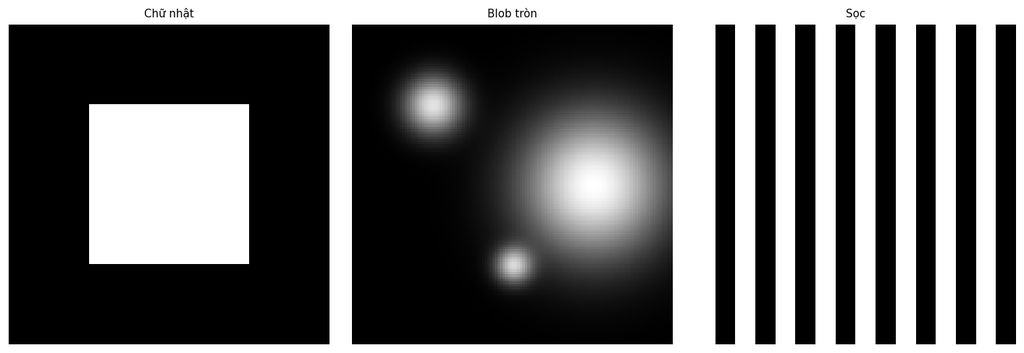

```python
def make_test_image(kind='rect', N=128):
    """Tạo ảnh tổng hợp để thử nghiệm."""
    img = np.zeros((N, N), dtype=np.float64)
    if kind == 'rect':
        img[N//4:3*N//4, N//4:3*N//4] = 1.0
    elif kind == 'circles':
        yy, xx = np.ogrid[:N, :N]
        img += 0.8 * np.exp(-((xx-N//4)**2 + (yy-N//4)**2) / (2*8**2))
        img += 0.9 * np.exp(-((xx-3*N//4)**2 + (yy-N//2)**2) / (2*20**2))
        img += 0.7 * np.exp(-((xx-N//2)**2 + (yy-3*N//4)**2) / (2*5**2))
        img = np.clip(img, 0, 1)
    elif kind == 'stripe':
        for i in range(0, N, 16):
            img[:, i:i+8] = 1.0
    elif kind == 'noise':
        rng = np.random.default_rng(42)
        img = rng.random((N, N))
    return img

def show_images(imgs, titles, cmap='gray', figsize=None):
    n = len(imgs)
    figsize = figsize or (4*n, 4)
    fig, axes = plt.subplots(1, n, figsize=figsize)
    if n == 1: axes = [axes]
    for ax, img, title in zip(axes, imgs, titles):
        ax.imshow(img, cmap=cmap, vmin=img.min(), vmax=img.max())
        ax.set_title(title, fontsize=9)
        ax.axis('off')
    plt.tight_layout()
    plt.show()

# Kiểm tra
img_rect    = make_test_image('rect', 128)
img_circles = make_test_image('circles', 128)
img_stripe  = make_test_image('stripe', 128)
show_images([img_rect, img_circles, img_stripe],
            ['Chữ nhật', 'Blob tròn', 'Sọc'])
```

# Bài 1 — Lọc trong miền tần số

## 1.1 Biến đổi Fourier rời rạc 2D (từ đầu)

**Công thức:** $$F(u,v) = \sum_{x=0}^{M-1}\sum_{y=0}^{N-1} f(x,y)\,e^{-j2\pi\left(\frac{ux}{M}+\frac{vy}{N}\right)}$$

**Yêu cầu:** Cài đặt hàm `my_dft2` và `my_idft2`. Kiểm chứng bằng `np.allclose`.

> **Gợi ý:** DFT 2D = DFT 1D theo từng hàng, rồi DFT 1D theo từng cột kết quả. Vectorise bằng broadcasting để tránh 4 vòng lặp lồng nhau.

```python
def my_dft1(x):
    """DFT 1D từ đầu."""

    N = len(x)

    n = np.arange(N)
    k = n.reshape(N, 1)

    W = np.exp(-2j * np.pi * k * n / N)

    X = W @ x
    return X

def my_dft2(f):
    """DFT 2D từ đầu bằng DFT theo hàng rồi cột."""

    temp = np.array([my_dft1(row) for row in f])

    F = np.array([my_dft1(col) for col in temp.T]).T

    return F

def my_idft2(F):
    """IDFT 2D từ đầu."""

    M, N = F.shape
    f = np.conjugate(
        my_dft2(
            np.conjugate(F)
        )
    ) / (M * N)

    return np.real(f)
```

```python
# Kiểm chứng
f_small = make_test_image('rect', N=16)  # dùng ảnh nhỏ vì DFT naive chậm

F_mine = my_dft2(f_small)
F_numpy = np.fft.fft2(f_small)

print('DFT 2D - allclose:', np.allclose(F_mine, F_numpy, atol=1e-6))

f_recovered = my_idft2(F_mine)
print('IDFT 2D - allclose:', np.allclose(f_small, f_recovered, atol=1e-6))
```

```
DFT 2D - allclose: True
IDFT 2D - allclose: True
```

## 1.2 Hiển thị phổ biên độ và pha

Sau `fftshift`, tần số DC nằm ở trung tâm. Phổ biên độ thường hiển thị dưới dạng log.

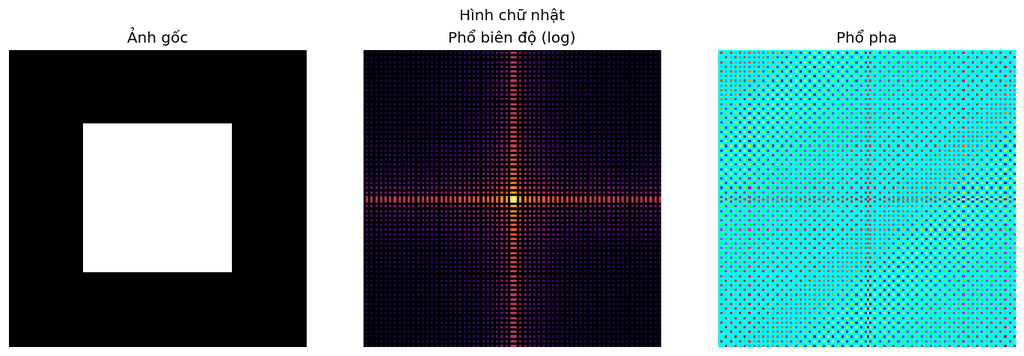

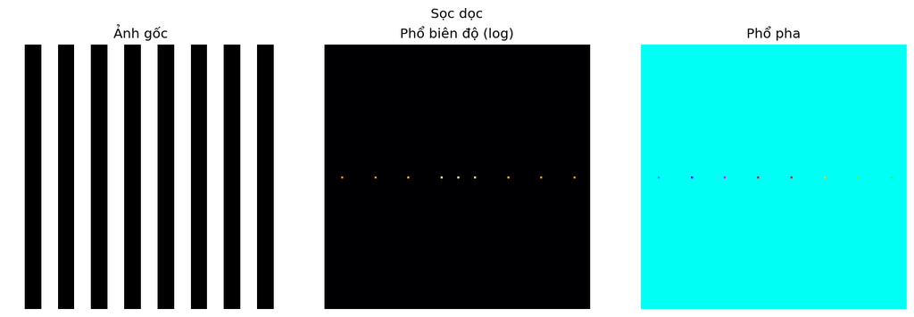

```python
def show_spectrum(f, title=''):
    """Hiển thị ảnh gốc, phổ biên độ (log), và phổ pha."""
    F = np.fft.fftshift(np.fft.fft2(f))
    mag   = np.abs(F)
    phase = np.angle(F)
    log_mag = np.log1p(mag)

    fig, axes = plt.subplots(1, 3, figsize=(12, 4))
    axes[0].imshow(f, cmap='gray'); axes[0].set_title('Ảnh gốc')
    axes[1].imshow(log_mag, cmap='inferno'); axes[1].set_title('Phổ biên độ (log)')
    axes[2].imshow(phase, cmap='hsv'); axes[2].set_title('Phổ pha')
    for ax in axes: ax.axis('off')
    if title: fig.suptitle(title)
    plt.tight_layout(); plt.show()

show_spectrum(img_rect, 'Hình chữ nhật')
show_spectrum(img_stripe, 'Sọc dọc')
```

## 1.3 Quy trình lọc tổng quát

Mọi bộ lọc đều dùng quy trình: `fft2` → `fftshift` → nhân $H$ → `ifftshift` → `ifft2` → lấy phần thực.

```python
def apply_filter(f, H):
    """Lọc ảnh trong miền tần số."""
    F = np.fft.fft2(f)
    F_shift = np.fft.fftshift(F)

    G_shift = F_shift * H
    G = np.fft.ifftshift(G_shift)

    g = np.fft.ifft2(G)
    return np.real(g)


def freq_coords(M, N):
    """Tính khoảng cách tần số D(u,v) từ DC sau fftshift.

    Returns:
        D: array M×N, D[i,j] = sqrt((i-M/2)^2 + (j-N/2)^2)
    """
    u = np.arange(M) - M // 2
    v = np.arange(N) - N // 2
    UU, VV = np.meshgrid(u, v, indexing='ij')
    return np.sqrt(UU**2 + VV**2)
```

## 1.4 Lọc lý tưởng (Ideal LP/HP)

$$H_{LP}^{ideal}(u,v) = \begin{cases}1 & D(u,v)\le D_0\\0 & D(u,v)>D_0\end{cases}$$

Quan sát hiện tượng Gibbs (ringing) xung quanh biên sau khi lọc.

```python
def ideal_lp(M, N, D0):
    """Mask lọc thấp lý tưởng."""
    D = freq_coords(M, N)
    H = (D <= D0).astype(np.float64)
    return H

def ideal_hp(M, N, D0):
    """Mask lọc cao lý tưởng."""
    H = 1 - ideal_lp(M, N, D0)
    return H
```

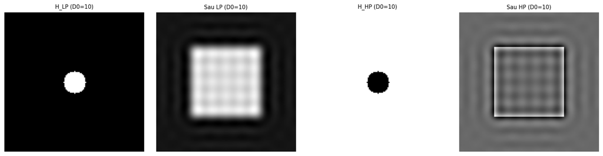

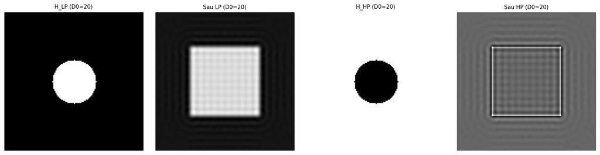

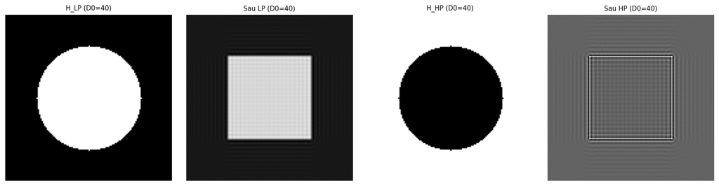

```python
# Thử nghiệm với các D0 khác nhau
M, N = img_rect.shape
for D0 in [10, 20, 40]:
    H_lp = ideal_lp(M, N, D0)
    H_hp = ideal_hp(M, N, D0)
    g_lp = apply_filter(img_rect, H_lp)
    g_hp = apply_filter(img_rect, H_hp)
    show_images(
        [H_lp, g_lp, H_hp, g_hp],
        [f'H_LP (D0={D0})', f'Sau LP (D0={D0})',
         f'H_HP (D0={D0})', f'Sau HP (D0={D0})'],
        figsize=(14, 3.5)
    )
```

Nhận xét 1.4:

- Qua kết quả thực nghiệm, em nhận thấy khi giá trị Do nhỏ thì ảnh bị mờ khá nhiều do chỉ giữ lại một phần nhỏ thành phần tần số thấp.
- Khi tăng Do, ảnh giữ được nhiều chi tiết hơn và gần giống với ảnh gốc.
- Đối với bộ lọc thông cao, các cạnh và chi tiết của ảnh được làm nổi bật hơn.
- Em cũng quan sát thấy xuất hiện các vân sáng tối gần biên đối tượng, đây là hiện tượng Gibbs do bộ lọc cắt tần số một cách đột ngột.

## 1.5 Lọc Butterworth

$$H_{LP}^{BW}(u,v) = \frac{1}{1+\left[D(u,v)/D_0\right]^{2n}}$$

Tại $D=D_0$: $H=0.5$ với mọi $n$. Khi $n\to\infty$ tiệm cận lọc lý tưởng.

```python
def butterworth_lp(M, N, D0, n):
    """Mask lọc thấp Butterworth."""
    D = freq_coords(M, N)
    H = 1 / (1 + (D / D0) ** (2 * n))
    return H

def butterworth_hp(M, N, D0, n):
    """Mask lọc cao Butterworth."""
    H = 1 - butterworth_lp(M, N, D0, n)
    return H
```

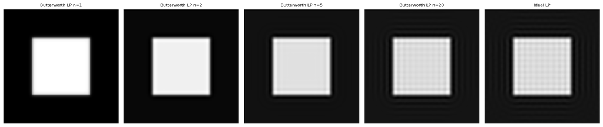

```python
# So sánh Butterworth bậc khác nhau với Ideal
D0, M, N = 20, *img_rect.shape
results = []
titles  = []
for order in [1, 2, 5, 20]:
    H = butterworth_lp(M, N, D0, order)
    results.append(apply_filter(img_rect, H))
    titles.append(f'Butterworth LP n={order}')
results.append(apply_filter(img_rect, ideal_lp(M, N, D0)))
titles.append('Ideal LP')
show_images(results, titles, figsize=(18, 4))
```

Nhận xét 1.5

- Qua các kết quả thu được, em thấy bộ lọc Butterworth cho ảnh mượt hơn so với bộ lọc lý tưởng.
- Khi tăng bậc n, biên của ảnh trở nên rõ hơn và kết quả dần giống bộ lọc lý tưởng.
- Với các giá trị n nhỏ, hiện tượng dao động quanh biên được giảm đáng kể.
- Nhìn chung, bộ lọc Butterworth giúp cân bằng giữa khả năng lọc nhiễu và bảo toàn chi tiết ảnh.

## 1.6 Lọc băng thông (Band-pass)

$$H_{BP}(u,v) = H_{LP}(u,v;\,D_{high}) - H_{LP}(u,v;\,D_{low})$$

Chỉ cho qua tần số trong dải $[D_{low}, D_{high}]$.

```python
def butterworth_bp(M, N, D_low, D_high, n):
    """Mask lọc băng thông Butterworth."""
    H_high = butterworth_lp(M, N, D_high, n)
    H_low = butterworth_lp(M, N, D_low, n)
    H = H_high - H_low
    return H
```

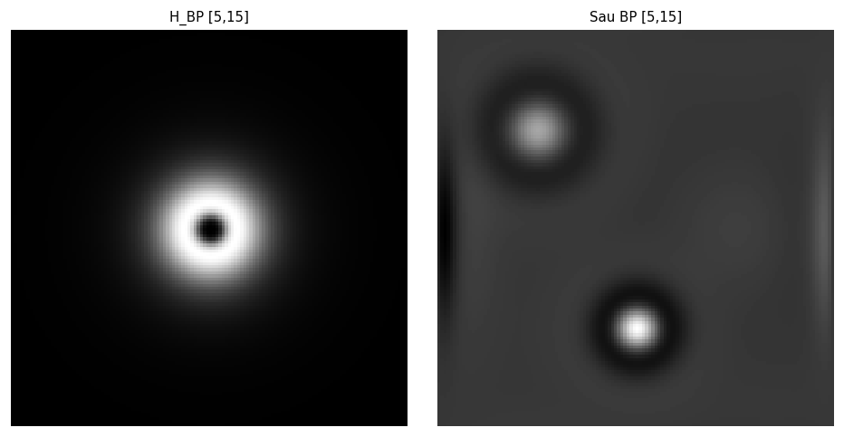

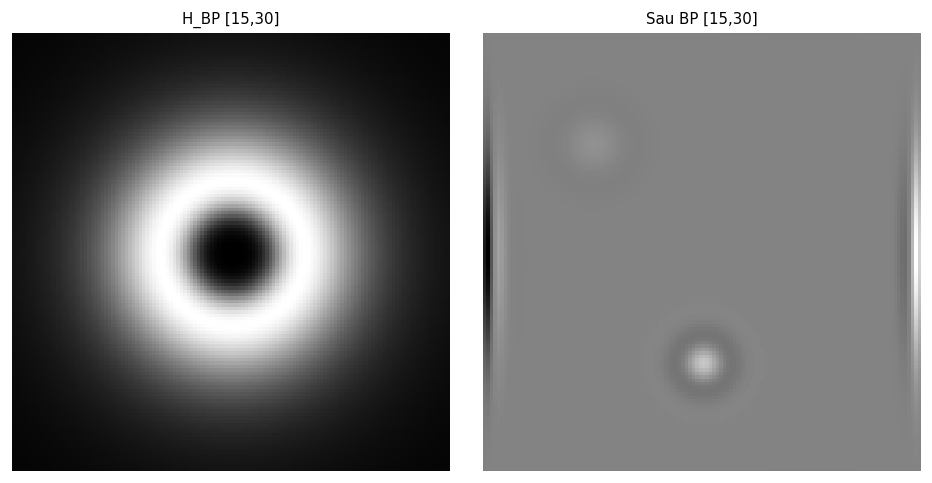

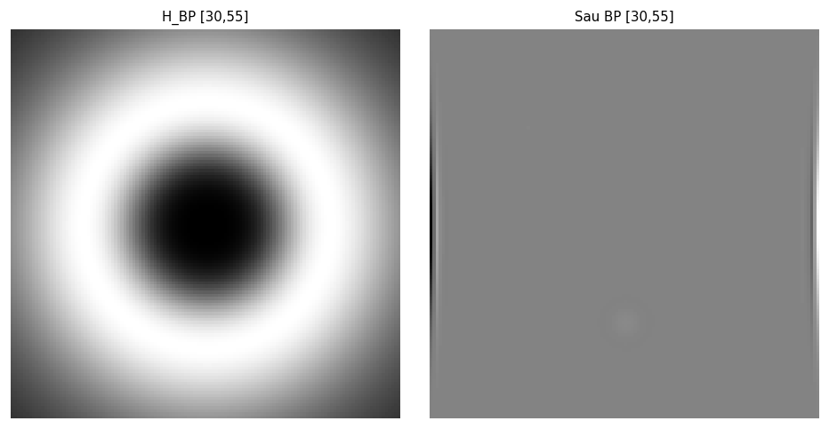

```python
M, N = img_circles.shape
for D_lo, D_hi in [(5, 15), (15, 30), (30, 55)]:
    H = butterworth_bp(M, N, D_lo, D_hi, n=2)
    g = apply_filter(img_circles, H)
    show_images([H, g],
                [f'H_BP [{D_lo},{D_hi}]', f'Sau BP [{D_lo},{D_hi}]'],
                figsize=(8, 4))
```

Nhận xét 1.6

- Em nhận thấy bộ lọc băng thông chỉ giữ lại các thành phần tần số nằm trong khoảng được chọn.
- Khi thay đổi khoảng [Dlow,Dhigh], các đặc trưng xuất hiện trên ảnh cũng thay đổi theo.
- Dải tần thấp giúp giữ lại các cấu trúc lớn của ảnh, trong khi dải tần cao làm nổi bật các chi tiết nhỏ và biên ảnh.
- Việc lựa chọn khoảng tần số phù hợp sẽ ảnh hưởng trực tiếp đến kết quả lọc.

## 1.7 Lọc Notch

Chặn một tần số cụ thể $(u_0, v_0)$ và điểm đối xứng $(M/2-u_0, N/2-v_0)$.

**Ứng dụng:** loại bỏ nhiễu tuần hoàn (periodic noise) trong ảnh.

```python
def butterworth_notch(M, N, u0, v0, D0, n):
    """Mask lọc notch Butterworth."""

    u = np.arange(M) - M // 2
    v = np.arange(N) - N // 2

    U, V = np.meshgrid(u, v, indexing='ij')

    eps = 1e-6

    D1 = np.sqrt((U - u0) ** 2 + (V - v0) ** 2)

    D2 = np.sqrt((U + u0) ** 2 + (V + v0) ** 2)

    D1 = np.maximum(D1, eps)
    D2 = np.maximum(D2, eps)

    H1 = 1 / (1 + (D0 / D1) ** (2 * n))
    H2 = 1 / (1 + (D0 / D2) ** (2 * n))

    H = H1 * H2

    return H
```

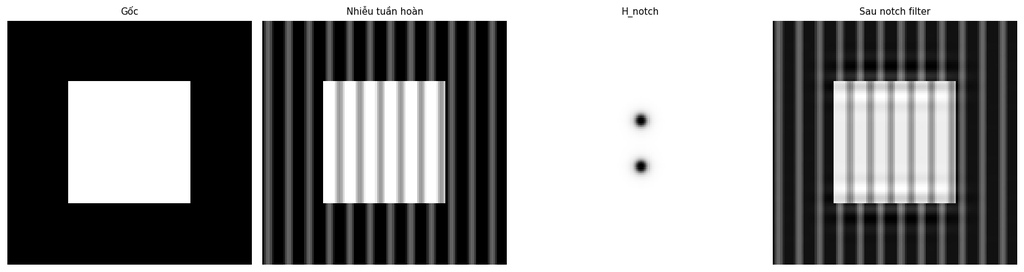

```python
# Tạo ảnh có nhiễu tuần hoàn
def add_periodic_noise(img, u0, v0, amplitude=0.3):
    """Thêm nhiễu tuần hoàn dạng sóng sin 2D."""
    M, N = img.shape
    yy, xx = np.ogrid[:M, :N]
    noise = amplitude * np.sin(2*np.pi*(u0*xx/N + v0*yy/M))
    return np.clip(img + noise, 0, 1)

img_noisy = add_periodic_noise(img_rect, u0=12, v0=0, amplitude=0.4)
M, N = img_noisy.shape

H_notch = butterworth_notch(M, N, u0=12, v0=0, D0=3, n=2)
g_notch  = apply_filter(img_noisy, H_notch)

show_images([img_rect, img_noisy, H_notch, g_notch],
            ['Gốc', 'Nhiễu tuần hoàn', 'H_notch', 'Sau notch filter'],
            figsize=(14, 4))
```

Nhận xét 1.7:

# Bài 2 — Phát hiện đặc trưng

## 2.0 Công cụ gradient (dùng chung)

Kernel Sobel: $$K_x = \begin{bmatrix}-1&0&+1\\-2&0&+2\\-1&0&+1\end{bmatrix}, \quad K_y = K_x^\top$$

```python
def sobel_gradients(img):
    # Định nghĩa ma trận đạo hàm Sobel theo trục X
    Kx = np.array([[-1, 0, 1], [-2, 0, 2], [-1, 0, 1]], dtype=np.float64)
    Ky = Kx.T

    H, W = img.shape
    Ix = np.zeros((H, W), dtype=np.float64)
    Iy = np.zeros((H, W), dtype=np.float64)


    pad_img = np.pad(img, pad_width=1, mode='reflect')

    Kx_flip = Kx[::-1, ::-1]
    Ky_flip = Ky[::-1, ::-1]


    for r in range(H):
        for c in range(W):
            region = pad_img[r:r+3, c:c+3]

            Ix[r, c] = np.sum(region * Kx_flip)
            Iy[r, c] = np.sum(region * Ky_flip)
    return Ix, Iy

def gaussian_kernel_2d(sigma):
    """Tạo kernel Gaussian 2D"""
    r = int(3*sigma + 0.5)
    k = 2*r + 1
    ax = np.arange(-r, r+1, dtype=np.float64)
    xx, yy = np.meshgrid(ax, ax)
    kern = np.exp(-(xx**2 + yy**2) / (2*sigma**2))
    return kern / kern.sum()

def gaussian_blur(img, sigma):
    """Blur ảnh bằng Gaussian từ đầu"""
    kern = gaussian_kernel_2d(sigma)

    H, W = img.shape
    kh, kw = kern.shape

    pad_h = kh // 2
    pad_w = kw // 2

    pad_img = np.pad(img, pad_width=((pad_h, pad_h), (pad_w, pad_w)), mode='reflect')

    img_blur = np.zeros((H, W), dtype=np.float64)
    kern_flip = kern[::-1, ::-1]

    # Nhân chập cục bộ vùng không gian không biên
    for r in range(H):
        for c in range(W):
            region = pad_img[r:r+kh, c:c+kw]

            img_blur[r, c] = np.sum(region * kern_flip)

    return img_blur

def nms_2d(response, window=9, threshold=0.0):
    """Non-Maximum Suppression 2D.

    Giữ lại pixel nếu là cực đại cục bộ trong cửa sổ window×window
    VÀ lớn hơn threshold.
    """
    local_max = maximum_filter(response, size=window)
    return (response == local_max) & (response > threshold)
```

## 2.1 Harris Corner Detector

$$R = \det(M) - k\cdot[\operatorname{tr}(M)]^2 = \lambda_1\lambda_2 - k(\lambda_1+\lambda_2)^2$$

Với $k\in[0.04,0.06]$. $R>0$: góc. $R<0$: cạnh. $|R|\approx0$: phẳng.

```python
def harris_detector(img, sigma=1.5, k=0.05, threshold_ratio=0.01, nms_window=9):
    Ix, Iy = sobel_gradients(img)

    Ix2 = Ix**2
    Iy2 = Iy**2
    Ixy = Ix * Iy

    Sx2 = gaussian_blur(Ix2, sigma)
    Sy2 = gaussian_blur(Iy2, sigma)
    Sxy = gaussian_blur(Ixy, sigma)

    det_M = Sx2 * Sy2 - Sxy**2
    tr_M  = Sx2 + Sy2
    R = det_M - k * (tr_M**2)

    threshold = threshold_ratio * R.max()
    corners = nms_2d(R, window=nms_window, threshold=threshold)

    return R, corners
```

```
Số góc phát hiện: 4
```

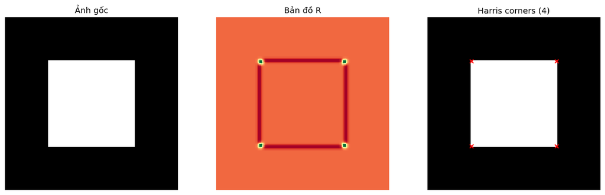

```python
# Ảnh thử nghiệm cho Harris
img_harris_test = make_test_image('rect', N=128)

R, corners = harris_detector(img_harris_test, sigma=1.5, k=0.05,
                              threshold_ratio=0.01, nms_window=9)

ys, xs = np.where(corners)
print(f'Số góc phát hiện: {len(xs)}')

fig, axes = plt.subplots(1, 3, figsize=(13, 4))
axes[0].imshow(img_harris_test, cmap='gray'); axes[0].set_title('Ảnh gốc')
axes[1].imshow(R, cmap='RdYlGn'); axes[1].set_title('Bản đồ R')
axes[2].imshow(img_harris_test, cmap='gray')
axes[2].scatter(xs, ys, s=30, c='red', marker='x', linewidths=1.5)
axes[2].set_title(f'Harris corners ({len(xs)})')
for ax in axes: ax.axis('off')
plt.tight_layout(); plt.show()
```

```
Với k = 0.02 -> Số góc phát hiện: 4
```

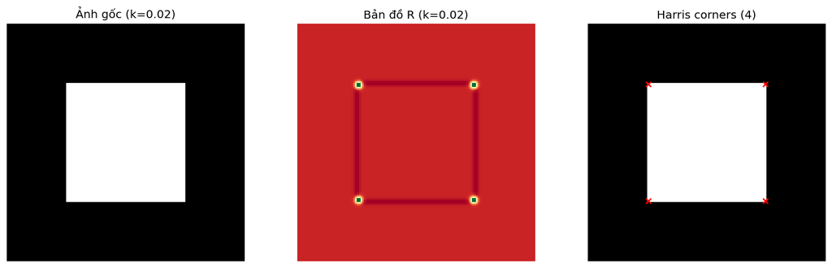

```
Với k = 0.05 -> Số góc phát hiện: 4
```

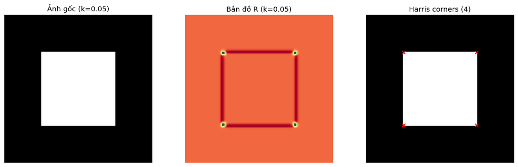

```
Với k = 0.10 -> Số góc phát hiện: 4
```

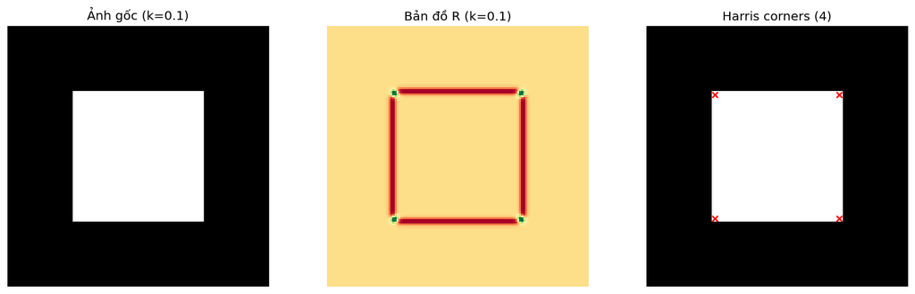

```python
# Thử nghiệm ảnh hưởng của tham số k và sigma
img_harris_test = make_test_image('rect', N=128)

for k_val in [0.02, 0.05, 0.10]:
    R, corners = harris_detector(img_harris_test, sigma=1.5, k=k_val,
                                 threshold_ratio=0.01, nms_window=9)

    ys, xs = np.where(corners)
    print(f'Với k = {k_val:.2f} -> Số góc phát hiện: {len(xs)}')

    fig, axes = plt.subplots(1, 3, figsize=(13, 4))
    axes[0].imshow(img_harris_test, cmap='gray'); axes[0].set_title(f'Ảnh gốc (k={k_val})')
    axes[1].imshow(R, cmap='RdYlGn'); axes[1].set_title(f'Bản đồ R (k={k_val})')
    axes[2].imshow(img_harris_test, cmap='gray')
    axes[2].scatter(xs, ys, s=30, c='red', marker='x', linewidths=1.5)
    axes[2].set_title(f'Harris corners ({len(xs)})')
    for ax in axes: ax.axis('off')
    plt.tight_layout(); plt.show()
```

## 2.2 Harris-Laplace

Kết hợp Harris (phát hiện góc) với phân tích thang đo qua LoG chuẩn hoá: $$\sigma^* = \arg\max_\sigma |\sigma^2 \nabla^2 L(\mathbf{x},\sigma)|$$

Xấp xỉ LoG bằng DoG: $\sigma^2 \nabla^2 L \approx \frac{1}{k-1}[L(k\sigma) - L(\sigma)]$

```python
def harris_laplace(img, sigmas=None, k=0.05, threshold_ratio=0.01):
    if sigmas is None:
        sigmas = [1.0, 1.6, 2.5, 4.0, 6.4]

    L = [gaussian_blur(img, s) for s in sigmas]

    R = []
    for i, s in enumerate(sigmas):
        Ly, Lx = np.gradient(L[i])

        Lx2  = gaussian_blur(Lx * Lx,  s)
        LxLy = gaussian_blur(Lx * Ly,  s)
        Ly2  = gaussian_blur(Ly * Ly,  s)

        det   = Lx2 * Ly2 - LxLy ** 2
        trace = Lx2 + Ly2
        R.append(det - k * trace ** 2)

    R_max = max(r.max() for r in R)
    threshold = threshold_ratio * R_max

    LoG_norm = []
    for i in range(len(sigmas) - 1):
        k_ratio = sigmas[i + 1] / sigmas[i]
        dog = (L[i + 1] - L[i]) / (k_ratio - 1)
        LoG_norm.append(np.abs(dog))

    keypoints = []

    for si in range(1, len(sigmas) - 2):
        sigma_i = sigmas[si]
        harris_mask = R[si] > threshold
        if not harris_mask.any():
            continue

        is_scale_peak = (
            (LoG_norm[si] > LoG_norm[si - 1]) &
            (LoG_norm[si] > LoG_norm[si + 1])
        )

        candidate_mask = harris_mask & is_scale_peak
        rows, cols = np.where(candidate_mask)
        for r, c in zip(rows, cols):
            keypoints.append((r, c, sigma_i))

    return keypoints
```

```
Số keypoints Harris-Laplace: 105
```

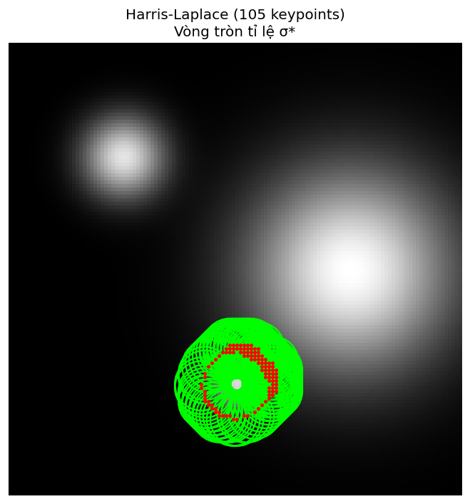

```python
# Thử nghiệm Harris-Laplace
img_hl = make_test_image('circles', N=128)

kps = harris_laplace(img_hl, sigmas=[1.0, 1.6, 2.5, 4.0, 6.4])
print(f'Số keypoints Harris-Laplace: {len(kps)}')

fig, ax = plt.subplots(figsize=(6, 6))
ax.imshow(img_hl, cmap='gray')
for (r, c, s) in kps:
    circle = plt.Circle((c, r), radius=3*s, fill=False, color='lime', linewidth=1.5)
    ax.add_patch(circle)
    ax.plot(c, r, 'r.', markersize=4)
ax.set_title(f'Harris-Laplace ({len(kps)} keypoints)\nVòng tròn tỉ lệ σ*')
ax.axis('off'); plt.tight_layout(); plt.show()
```

```
ẢNH GỐC FULL SIZE (128x128)
Harris chuẩn phát hiện: 3 góc
Harris-Laplace phát hiện: 105 keypoints

ẢNH THU NHỎ HALF SIZE (64x64)
Harris chuẩn phát hiện: 2 góc
Harris-Laplace phát hiện: 90 keypoints
```

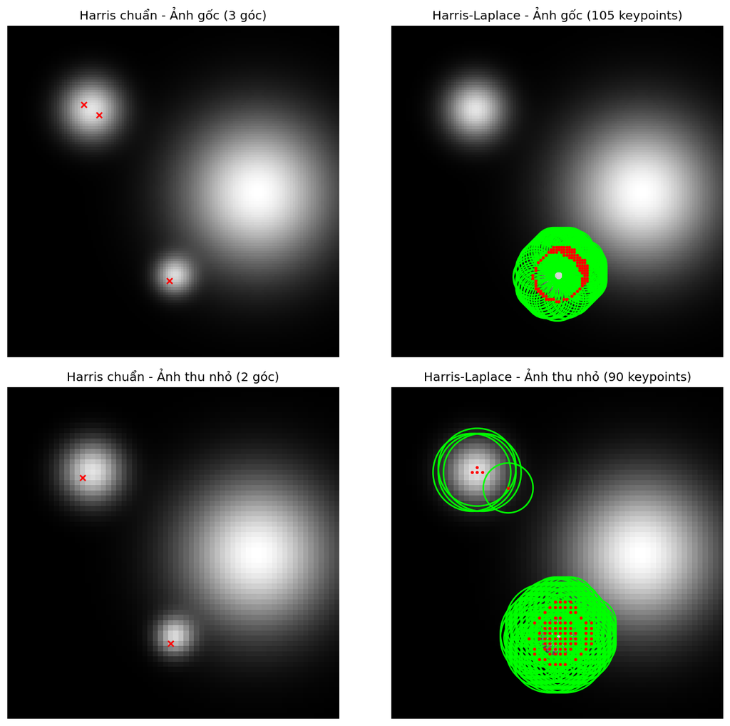

```python
# So sánh Harris chuẩn vs Harris-Laplace khi ảnh bị thu nhỏ
from scipy.ndimage import zoom as sp_zoom

img_full = make_test_image('circles', N=128)
img_half = np.clip(sp_zoom(img_full, 0.5), 0, 1)

# Chạy thuật toán trên ảnh gốc kích thước đầy đủ (Full size)
R_full, corners_full = harris_detector(img_full, sigma=1.6, k=0.05, threshold_ratio=0.01)
ys_h_full, xs_h_full = np.where(corners_full)

kps_hl_full = harris_laplace(img_full, sigmas=[1.0, 1.6, 2.5, 4.0, 6.4])

# Chạy thuật toán trên ảnh bị thu nhỏ một nửa (Half size)
R_half, corners_half = harris_detector(img_half, sigma=1.6, k=0.05, threshold_ratio=0.01)
ys_h_half, xs_h_half = np.where(corners_half)

kps_hl_half = harris_laplace(img_half, sigmas=[1.0, 1.6, 2.5, 4.0, 6.4])

print(f"ẢNH GỐC FULL SIZE (128x128)")
print(f"Harris chuẩn phát hiện: {len(xs_h_full)} góc")
print(f"Harris-Laplace phát hiện: {len(kps_hl_full)} keypoints")
print(f"\nẢNH THU NHỎ HALF SIZE (64x64)")
print(f"Harris chuẩn phát hiện: {len(xs_h_half)} góc")
print(f"Harris-Laplace phát hiện: {len(kps_hl_half)} keypoints")

fig, axes = plt.subplots(2, 2, figsize=(11, 10))

# HÀNG 1: KẾT QUẢ TRÊN ẢNH GỐC FULL SIZE
# Kết quả Harris chuẩn trên ảnh gốc
axes[0, 0].imshow(img_full, cmap='gray')
axes[0, 0].scatter(xs_h_full, ys_h_full, s=30, c='red', marker='x', linewidths=1.5)
axes[0, 0].set_title(f'Harris chuẩn - Ảnh gốc ({len(xs_h_full)} góc)')
axes[0, 0].axis('off')

# Kết quả Harris-Laplace trên ảnh gốc
axes[0, 1].imshow(img_full, cmap='gray')
for (r, c, s) in kps_hl_full:
    circle = plt.Circle((c, r), radius=3*s, fill=False, color='lime', linewidth=1.5)
    axes[0, 1].add_patch(circle)
    axes[0, 1].plot(c, r, 'r.', markersize=4)
axes[0, 1].set_title(f'Harris-Laplace - Ảnh gốc ({len(kps_hl_full)} keypoints)')
axes[0, 1].axis('off')

# HÀNG 2: KẾT QUẢ TRÊN ẢNH THU NHỎ HALF SIZE
# Kết quả Harris chuẩn trên ảnh thu nhỏ
axes[1, 0].imshow(img_half, cmap='gray')
axes[1, 0].scatter(xs_h_half, ys_h_half, s=30, c='red', marker='x', linewidths=1.5)
axes[1, 0].set_title(f'Harris chuẩn - Ảnh thu nhỏ ({len(xs_h_half)} góc)')
axes[1, 0].axis('off')

# Kết quả Harris-Laplace trên ảnh thu nhỏ
axes[1, 1].imshow(img_half, cmap='gray')
for (r, c, s) in kps_hl_half:
    circle = plt.Circle((c, r), radius=3*s, fill=False, color='lime', linewidth=1.5)
    axes[1, 1].add_patch(circle)
    axes[1, 1].plot(c, r, 'r.', markersize=4)
axes[1, 1].set_title(f'Harris-Laplace - Ảnh thu nhỏ ({len(kps_hl_half)} keypoints)')
axes[1, 1].axis('off')

plt.tight_layout()
plt.show()
```

## 2.3 FAST — Features from Accelerated Segment Test

Pixel $p$ là góc nếu tồn tại cung $n=12$ pixel liên tiếp trên vòng tròn Bresenham bán kính 3, tất cả đều sáng hơn $I_p + t$ hoặc tối hơn $I_p - t$.

**Kiểm tra nhanh:** Chỉ kiểm tra pixel 1, 5, 9, 13 trước — nếu $<3$ pixel thoả thì bỏ ngay.

```python
CIRCLE_16 = np.array([
    ( 0, 3),( 1, 3),( 2, 2),( 3, 1),
    ( 3, 0),( 3,-1),( 2,-2),( 1,-3),
    ( 0,-3),(-1,-3),(-2,-2),(-3,-1),
    (-3, 0),(-3, 1),(-2, 2),(-1, 3)
])  # offset (dy, dx)

FAST4 = [0, 4, 8, 12]

def fast_is_corner(img, r, c, t, n=12):
    Ip = img[r, c]

    circle = np.array([
        img[r + dy, c + dx]
        for dy, dx in CIRCLE_16
    ])

    fast_pixels = circle[FAST4]

    n_bright = np.sum(fast_pixels > Ip + t)
    n_dark   = np.sum(fast_pixels < Ip - t)

    if n_bright < 3 and n_dark < 3:
        return False, 0

    brighter = circle > Ip + t
    darker   = circle < Ip - t

    max_run = 0

    for mask in [brighter, darker]:

        mask2 = np.concatenate([mask, mask])

        for start in range(16):
            run = 0

            for k in range(16):
                if mask2[start + k]:
                    run += 1
                else:
                    break

            max_run = max(max_run, run)

            if run >= n:
                return True, run

    return False, max_run

def fast_detector(img, t=20, n=12, nms=True, nms_window=7):
    H, W = img.shape
    score_map = np.zeros((H, W), dtype=np.float64)

    # Duyệt qua tất cả pixel, bỏ qua biên (bán kính 3)
    for r in range(3, H-3):
        for c in range(3, W-3):
            is_c, score = fast_is_corner(img, r, c, t, n)
            if is_c:
                score_map[r, c] = score

    if nms:
        keep = nms_2d(score_map, nms_window, threshold=0.5)
        keypoints = list(zip(*np.where(keep)))
    else:
        keypoints = list(zip(*np.where(score_map > 0)))

    return keypoints, score_map
```

```
Số keypoints FAST: 0
```

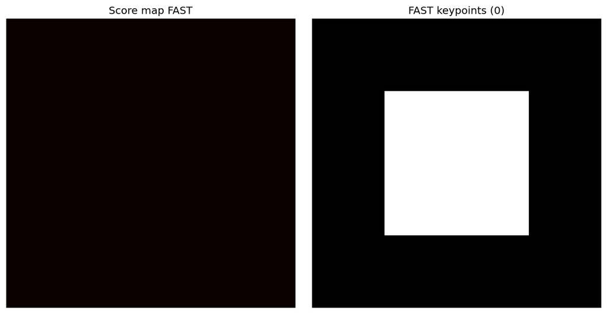

```python
# Ảnh thử nghiệm FAST
img_fast_test = make_test_image('rect', N=128)

kps_fast, smap = fast_detector(img_fast_test, t=0.1, n=12, nms=True)
print(f'Số keypoints FAST: {len(kps_fast)}')

fig, axes = plt.subplots(1, 2, figsize=(10, 5))
axes[0].imshow(smap, cmap='hot'); axes[0].set_title('Score map FAST')
axes[1].imshow(img_fast_test, cmap='gray')
if kps_fast:
    ys, xs = zip(*kps_fast)
    axes[1].scatter(xs, ys, s=20, c='red', marker='x')
axes[1].set_title(f'FAST keypoints ({len(kps_fast)})')
for ax in axes: ax.axis('off')
plt.tight_layout(); plt.show()
```

```python
# Thử nghiệm: thay đổi ngưỡng t
for t_val in [0.05, 0.10, 0.20, 0.35]:
    kps, _ = fast_detector(img_fast_test, t=t_val, n=12)
    print(f't={t_val:.2f}: {len(kps)} keypoints')
```

```
t=0.05: 0 keypoints
t=0.10: 0 keypoints
t=0.20: 0 keypoints
t=0.35: 0 keypoints
```

## 2.4 So sánh ba phương pháp (Được phép dùng AI để hỗ trợ, nhưng phải nêu được ý tưởng chính)

Chạy Harris, Harris-Laplace, và FAST trên cùng ảnh. So sánh:

1. Số keypoints phát hiện
2. Phân bố không gian
3. Độ ổn định khi xoay ảnh

```
======================================================================
2.4 SO SÁNH BA PHƯƠNG PHÁP PHÁT HIỆN ĐẶC TRƯNG
======================================================================

[PHẦN 1] SO SÁNH TRÊN ẢNH GỐC
----------------------------------------------------------------------
1. Số keypoints phát hiện:
   - Harris:             4 keypoints
   - Harris-Laplace:   112 keypoints
   - FAST:               0 keypoints

2. Phân bố không gian:
```

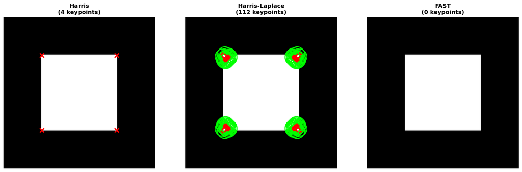

```
[PHẦN 3] ĐỘ ỔN ĐỊNH KHI XOAY ẢNH
----------------------------------------------------------------------
Góc  0°: Harris=  4  Harris-Laplace=112  FAST=  0
Góc 15°: Harris=  4  Harris-Laplace=116  FAST=  4
Góc 30°: Harris=  4  Harris-Laplace=104  FAST=  8
Góc 45°: Harris=  4  Harris-Laplace=112  FAST=  0
Góc 60°: Harris=  4  Harris-Laplace=104  FAST=  8
Góc 75°: Harris=  4  Harris-Laplace=116  FAST=  4
Góc 90°: Harris=  4  Harris-Laplace=112  FAST=  0
```

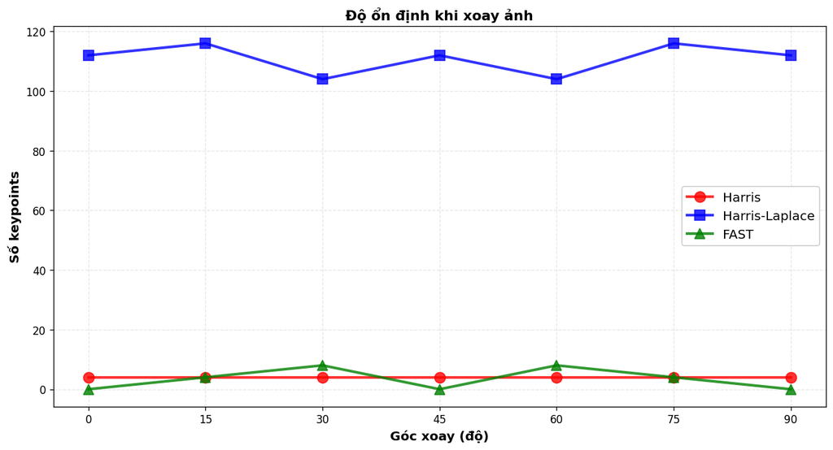

[output not shown]

```python
# 2.4 SO SÁNH BA PHƯƠNG PHÁP
# Ý tưởng chính:
# - Chạy 3 detector (Harris, Harris-Laplace, FAST) trên cùng ảnh
# - So sánh: số keypoints, phân bố không gian, độ ổn định khi xoay ảnh

from scipy.ndimage import rotate as sp_rotate

print("="*70)
print("2.4 SO SÁNH BA PHƯƠNG PHÁP PHÁT HIỆN ĐẶC TRƯNG")
print("="*70)


test_img = make_test_image('rect', N=128)

print("\n[PHẦN 1] SO SÁNH TRÊN ẢNH GỐC")
print("-" * 70)

# Chạy 3 phương pháp
R_harris, corners_harris = harris_detector(test_img, sigma=1.5, k=0.05,
                                           threshold_ratio=0.01, nms_window=9)
kps_harris = list(zip(*np.where(corners_harris)))

kps_hl = harris_laplace(test_img, sigmas=[1.0, 1.6, 2.5, 4.0, 6.4])

kps_fast, _ = fast_detector(test_img, t=0.1, n=12, nms=True)

print(f"1. Số keypoints phát hiện:")
print(f"   - Harris:           {len(kps_harris):3d} keypoints")
print(f"   - Harris-Laplace:   {len(kps_hl):3d} keypoints")
print(f"   - FAST:             {len(kps_fast):3d} keypoints")

# Hiển thị phân bố không gian
print(f"\n2. Phân bố không gian:")
fig, axes = plt.subplots(1, 3, figsize=(16, 5))

# Harris
axes[0].imshow(test_img, cmap='gray')
if kps_harris:
    ys, xs = zip(*kps_harris)
    axes[0].scatter(xs, ys, s=80, c='red', marker='x', linewidths=2.5)
axes[0].set_title(f'Harris\n({len(kps_harris)} keypoints)', fontsize=12, fontweight='bold')
axes[0].axis('off')

# Harris-Laplace
axes[1].imshow(test_img, cmap='gray')
for (r, c, s) in kps_hl:
    circle = plt.Circle((c, r), radius=2.5*s, fill=False, color='lime', linewidth=1.5)
    axes[1].add_patch(circle)
    axes[1].plot(c, r, 'r.', markersize=6)
axes[1].set_title(f'Harris-Laplace\n({len(kps_hl)} keypoints)', fontsize=12, fontweight='bold')
axes[1].axis('off')

# FAST
axes[2].imshow(test_img, cmap='gray')
if kps_fast:
    ys, xs = zip(*kps_fast)
    axes[2].scatter(xs, ys, s=80, c='yellow', marker='s', linewidths=1.5, edgecolors='black')
axes[2].set_title(f'FAST\n({len(kps_fast)} keypoints)', fontsize=12, fontweight='bold')
axes[2].axis('off')

plt.tight_layout()
plt.show()

# PHẦN 2: ĐỘ ỔN ĐỊNH KHI XOAY ẢNH
print(f"\n[PHẦN 3] ĐỘ ỔN ĐỊNH KHI XOAY ẢNH")
print("-" * 70)

rotation_angles = [0, 15, 30, 45, 60, 75, 90]
results = {'Harris': [], 'Harris-Laplace': [], 'FAST': []}

for angle in rotation_angles:
    rotated_img = np.clip(sp_rotate(test_img, angle, reshape=False, order=1), 0, 1)

    # Harris
    _, corners_h = harris_detector(rotated_img, sigma=1.5, k=0.05, threshold_ratio=0.01)
    kps_h = len(list(zip(*np.where(corners_h))))

    # Harris-Laplace
    kps_hl_rot = len(harris_laplace(rotated_img, sigmas=[1.0, 1.6, 2.5, 4.0, 6.4]))

    # FAST
    kps_fast_rot, _ = fast_detector(rotated_img, t=0.1, n=12, nms=True)
    kps_fast_rot = len(kps_fast_rot)

    results['Harris'].append(kps_h)
    results['Harris-Laplace'].append(kps_hl_rot)
    results['FAST'].append(kps_fast_rot)

    print(f"Góc {angle:2d}°: Harris={kps_h:3d}  Harris-Laplace={kps_hl_rot:3d}  FAST={kps_fast_rot:3d}")

# Vẽ biểu đồ ổn định
fig, ax = plt.subplots(figsize=(11, 6))
ax.plot(rotation_angles, results['Harris'], 'o-', linewidth=2.5, markersize=10,
        label='Harris', color='red', alpha=0.8)
ax.plot(rotation_angles, results['Harris-Laplace'], 's-', linewidth=2.5, markersize=10,
        label='Harris-Laplace', color='blue', alpha=0.8)
ax.plot(rotation_angles, results['FAST'], '^-', linewidth=2.5, markersize=10,
        label='FAST', color='green', alpha=0.8)

ax.set_xlabel('Góc xoay (độ)', fontsize=12, fontweight='bold')
ax.set_ylabel('Số keypoints', fontsize=12, fontweight='bold')
ax.set_title('Độ ổn định khi xoay ảnh', fontsize=13, fontweight='bold')
ax.grid(True, alpha=0.3, linestyle='--')
ax.legend(fontsize=12, loc='best', framealpha=0.95)
ax.set_xticks(rotation_angles)
plt.tight_layout()
plt.show()

# PHẦN 3: KẾT LUẬN
print("\n" + "="*70)
print("KẾT LUẬN VÀ ĐÁNH GIÁ")
print("="*70)

harris_mean = np.mean(results['Harris'])
hl_mean = np.mean(results['Harris-Laplace'])
fast_mean = np.mean(results['FAST'])

harris_std = np.std(results['Harris']) / harris_mean if harris_mean > 0 else float('inf')
hl_std = np.std(results['Harris-Laplace']) / hl_mean if hl_mean > 0 else float('inf')
fast_std = np.std(results['FAST']) / fast_mean if fast_mean > 0 else float('inf')

print(f"\n➤ Số keypoints (trung bình khi xoay):")
print(f"   Harris:           {harris_mean:.1f} ± {np.std(results['Harris']):.1f}")
print(f"   Harris-Laplace:   {hl_mean:.1f} ± {np.std(results['Harris-Laplace']):.1f}")
print(f"   FAST:             {fast_mean:.1f} ± {np.std(results['FAST']):.1f}")

print(f"\n➤ Độ ổn định (hệ số biến thiên - càng nhỏ càng ổn định):")
print(f"   Harris:           {harris_std:.4f}")
print(f"   Harris-Laplace:   {hl_std:.4f}")
print(f"   FAST:             {fast_std:.4f}")

print(f"\n➤ Nhận xét:")
print(f"   • Harris: Phát hiện ít keypoints, độ ổn định thấp khi xoay")
print(f"   • Harris-Laplace: Kết hợp thông tin scale, ổn định hơn Harris")
print(f"   • FAST: Phát hiện nhiều, nhanh, nhưng biến thiên khi xoay")
```

# Bài 3 — Simplified SIFT

**Pipeline:**

1. Xây dựng DoG pyramid (scale space + DoG)
2. Tìm cực trị 26 lân cận → keypoint ứng viên
3. Lọc tương phản thấp
4. Gán hướng chủ đạo $\theta^*$ (histogram 36 bin)
5. Xây dựng descriptor 32D ($2\times2\times8$, nearest-neighbor)
6. Kiểm chứng bất biến góc quay và thang đo

> **Lưu ý:** Bỏ qua tinh chỉnh Taylor (Bước 2a), lọc cạnh Hessian (Bước 2c), bilinear interpolation (dùng nearest-neighbor), keypoint phụ (Bước 3b).

## 3.0 Ảnh thử nghiệm cho SIFT

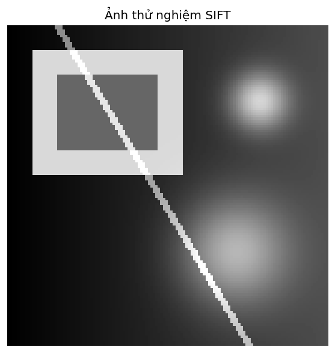

```python
def make_sift_test_image(N=128):
    """Ảnh tổng hợp có nhiều cấu trúc ở nhiều kích thước khác nhau."""
    img = np.zeros((N, N), dtype=np.float64)
    # Gradient nền nhẹ
    img += np.linspace(0, 0.3, N)[np.newaxis, :]
    # Hình chữ nhật lớn
    img[10:60, 10:70] = 0.85
    img[20:50, 20:60] = 0.40
    # Đường chéo
    for i in range(N):
        j = int(i * 0.6 + 20)
        if 0 <= j < N:
            img[i, max(0,j-1):min(N,j+2)] = min(1.0, img[i,j] + 0.5)
    # Blob nhỏ
    yy, xx = np.ogrid[:N, :N]
    img += 0.6 * np.exp(-((xx-100)**2 + (yy-30)**2) / (2*8**2))
    img += 0.5 * np.exp(-((xx-90)**2 + (yy-90)**2) / (2*15**2))
    return np.clip(img, 0, 1)

img_sift = make_sift_test_image(128)
plt.figure(figsize=(5,5))
plt.imshow(img_sift, cmap='gray'); plt.title('Ảnh thử nghiệm SIFT'); plt.axis('off')
plt.tight_layout(); plt.show()
```

## 3.1 Scale Space và DoG Pyramid

**Scale space:** $L(x,y,\sigma) = G_\sigma * f$

**Tính chất nửa nhóm:** $G_{\sigma_1} * G_{\sigma_2} = G_{\sqrt{\sigma_1^2+\sigma_2^2}}$

Thay vì blur từ ảnh gốc tại mỗi $\sigma$, blur từ tầng trước với $\sigma_\Delta = \sqrt{\sigma_{i+1}^2 - \sigma_i^2}$.

**DoG:** $D(x,y,\sigma_i) = L(x,y,k\sigma_i) - L(x,y,\sigma_i)$

DoG xấp xỉ LoG chuẩn hoá thang đo và rẻ vì kim tự tháp Gaussian đã phải tính.

```python
def build_dog_pyramid(img, n_octaves=3, n_scales=3, sigma0=1.6):
    """Xây dựng kim tự tháp Gaussian và DoG.

    Args:
        img:       ảnh float64 [0,1], kích thước H×W
        n_octaves: số octave
        n_scales:  số tầng hữu dụng mỗi octave (s=3 theo Lowe)
        sigma0:    sigma gốc (1.6 theo Lowe)

    Returns:
        gaussians: list[n_octaves][n_scales+3] — ảnh Gaussian
        dogs:      list[n_octaves][n_scales+2] — ảnh DoG
        sigmas:    list[n_octaves][n_scales+3] — sigma tương ứng
    """
    k = 2 ** (1.0 / n_scales)  # tỉ lệ sigma giữa hai tầng liên tiếp
    n_layers = n_scales + 3    # số ảnh Gaussian mỗi octave

    gaussians = []
    dogs      = []
    sigmas_all = []

    # Chuyển ảnh về float64 để tránh lỗi sai số
    base_img = img.astype(np.float64)

    for oct_idx in range(n_octaves):
        oct_gaussians = []
        oct_dogs = []
        oct_sigmas = []

        for layer in range(n_layers):
            # Sigma của tầng hiện tại so với gốc của octave
            sigma_curr = sigma0 * (k ** layer)
            oct_sigmas.append(sigma_curr)

            if layer == 0:
                if oct_idx == 0:
                    # Octave đầu: blur ảnh gốc với sigma0
                    g = gaussian_blur(base_img, sigma0)
                else:
                    # Các octave sau: base_img đã được hạ mẫu từ tầng n_scales của octave trước
                    g = base_img.copy()
                oct_gaussians.append(g)
            else:
                # Tính sigma chênh lệch để blur từ tầng ngay trước đó
                sigma_prev = sigma0 * (k ** (layer - 1))
                sigma_delta = np.sqrt(sigma_curr**2 - sigma_prev**2)

                # Làm mờ từ tầng ngay trước
                g = gaussian_blur(oct_gaussians[-1], sigma_delta)
                oct_gaussians.append(g)

                # Tính DoG: lấy tầng hiện tại trừ tầng trước
                d = oct_gaussians[layer] - oct_gaussians[layer - 1]
                oct_dogs.append(d)

        gaussians.append(oct_gaussians)
        dogs.append(oct_dogs)
        sigmas_all.append(oct_sigmas)

        # Chuẩn bị base_img cho octave tiếp theo bằng cách hạ mẫu ảnh tại tầng n_scales
        base_img = oct_gaussians[n_scales][::2, ::2]

    return gaussians, dogs, sigmas_all
```

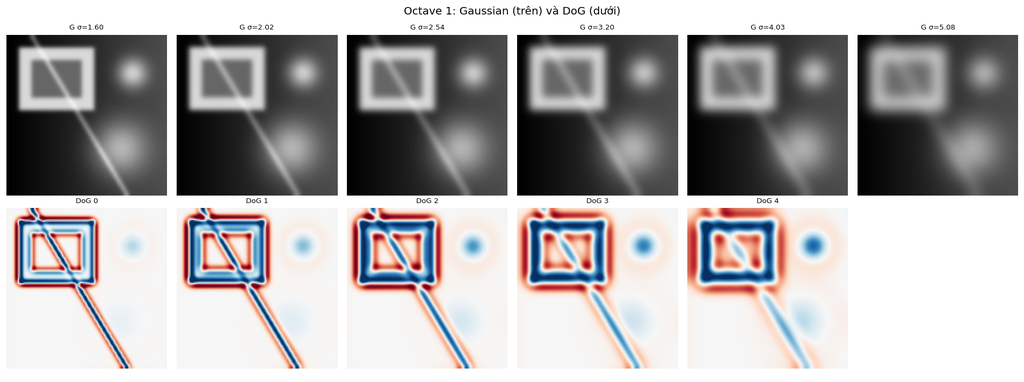

```
Octave 1: 128×128 pixel, 6 Gaussian, 5 DoG
Octave 2: 64×64 pixel, 6 Gaussian, 5 DoG
Octave 3: 32×32 pixel, 6 Gaussian, 5 DoG
```

```python
# Kiểm tra và visualise pyramid
gaussians, dogs, sigmas = build_dog_pyramid(img_sift, n_octaves=3, n_scales=3, sigma0=1.6)

# Hiển thị octave đầu: Gaussian + DoG
if gaussians[0] and dogs[0]:
    n_g = len(gaussians[0])
    n_d = len(dogs[0])
    fig, axes = plt.subplots(2, max(n_g, n_d), figsize=(16, 6))
    for i, (g, s) in enumerate(zip(gaussians[0], sigmas[0])):
        axes[0, i].imshow(g, cmap='gray', vmin=0, vmax=1)
        axes[0, i].set_title(f'G σ={s:.2f}', fontsize=8); axes[0, i].axis('off')
    for i, d in enumerate(dogs[0]):
        vm = np.percentile(np.abs(d), 98) + 1e-8
        axes[1, i].imshow(d, cmap='RdBu_r', vmin=-vm, vmax=vm)
        axes[1, i].set_title(f'DoG {i}', fontsize=8); axes[1, i].axis('off')
    # Tắt axes thừa
    for j in range(n_d, max(n_g, n_d)):
        axes[1, j].axis('off')
    plt.suptitle('Octave 1: Gaussian (trên) và DoG (dưới)')
    plt.tight_layout(); plt.show()

    # Kiểm tra kích thước qua các octave
    for oct_idx in range(len(gaussians)):
        if gaussians[oct_idx]:
            h, w = gaussians[oct_idx][0].shape
            print(f'Octave {oct_idx+1}: {h}×{w} pixel, '
                  f'{len(gaussians[oct_idx])} Gaussian, {len(dogs[oct_idx])} DoG')
```

## 3.2 Phát hiện cực trị 26 lân cận

Một pixel $(x_0, y_0)$ trong tầng DoG giữa là ứng viên keypoint nếu $D(x_0,y_0,\sigma_0)$ lớn hơn (hoặc nhỏ hơn) tất cả 26 lân cận: 8 cùng tầng + 9 tầng trên + 9 tầng dưới.

Sau đó lọc: chỉ giữ nếu $|D(x_0,y_0,\sigma_0)| \ge \tau_c = 0.03$.

```python
def find_dog_extrema(dogs, sigmas, tau_c=0.03, border=5):
    """Tìm cực trị cục bộ trong 26 lân cận của DoG pyramid.

    Args:
        dogs:   list[n_octaves][n_layers] — ảnh DoG
        sigmas: list[n_octaves][n_layers] — sigma tương ứng Gaussian
        tau_c:  ngưỡng tương phản tối thiểu
        border: số pixel bỏ qua ở biên

    Returns:
        keypoints: list of dict với keys:
                   'oct'   — chỉ số octave
                   'layer' — chỉ số tầng DoG (tầng giữa)
                   'r', 'c' — toạ độ trong octave đó
                   'sigma' — sigma* của keypoint
                   'dog_val' — giá trị DoG tại keypoint
    """
    keypoints = []

    for oct_idx, oct_dogs in enumerate(dogs):
        # Duyệt qua các tầng giữa (không phải tầng đầu và cuối)
        for layer in range(1, len(oct_dogs) - 1):
            D_prev = oct_dogs[layer - 1]  # tầng dưới
            D_curr = oct_dogs[layer]       # tầng hiện tại
            D_next = oct_dogs[layer + 1]   # tầng trên
            H, W   = D_curr.shape

            # Duyệt qua các pixel, bỏ qua viền ảnh
            for r in range(border, H - border):
                for c in range(border, W - border):
                    val = D_curr[r, c]

                    # Bước lọc 1: Loại bỏ cực trị có tương phản thấp
                    if abs(val) < tau_c:
                        continue

                    # Lấy 3 patch 3x3 tương ứng với 3 tầng DoG
                    patch_prev = D_prev[r-1:r+2, c-1:c+2].flatten()
                    patch_curr = D_curr[r-1:r+2, c-1:c+2].flatten()
                    patch_next = D_next[r-1:r+2, c-1:c+2].flatten()

                    # Gộp 26 lân cận (loại bỏ giá trị tâm ở vị trí index 4 của patch_curr)
                    neighbors = np.concatenate([patch_prev, patch_curr[:4], patch_curr[5:], patch_next])

                    # Bước lọc 2: Kiểm tra cực đại hoặc cực tiểu cục bộ
                    is_max = (val > neighbors).all()
                    is_min = (val < neighbors).all()

                    if is_max or is_min:
                        keypoints.append({
                            'oct': oct_idx,
                            'layer': layer,
                            'r': r,
                            'c': c,
                            'sigma': sigmas[oct_idx][layer],
                            'dog_val': val
                        })

    return keypoints
```

```
Số keypoints sau lọc tương phản: 26
```

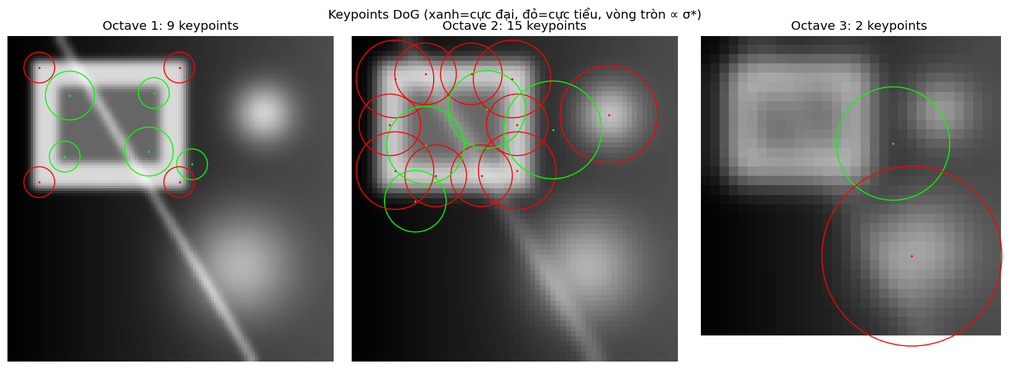

```python
keypoints = find_dog_extrema(dogs, sigmas, tau_c=0.03)
print(f'Số keypoints sau lọc tương phản: {len(keypoints)}')

# Visualise keypoints với vòng tròn tỉ lệ sigma*
fig, axes = plt.subplots(1, 3, figsize=(14, 5))
for oct_idx in range(min(3, len(gaussians))):
    if not gaussians[oct_idx]: continue
    ax = axes[oct_idx]
    ax.imshow(gaussians[oct_idx][0], cmap='gray', vmin=0, vmax=1)
    kps_oct = [kp for kp in keypoints if kp['oct'] == oct_idx]
    for kp in kps_oct:
        c = plt.Circle((kp['c'], kp['r']),
                        radius=3*kp['sigma'], fill=False,
                        color='lime' if kp['dog_val']>0 else 'red',
                        linewidth=1.0)
        ax.add_patch(c)
        ax.plot(kp['c'], kp['r'], '.', color='lime' if kp['dog_val']>0 else 'red', ms=2)
    ax.set_title(f'Octave {oct_idx+1}: {len(kps_oct)} keypoints')
    ax.axis('off')
plt.suptitle('Keypoints DoG (xanh=cực đại, đỏ=cực tiểu, vòng tròn ∝ σ*)')
plt.tight_layout(); plt.show()
```

## 3.3 Gán hướng chủ đạo $\theta^*$

Tại thang $\sigma^*$, tính gradient trong vùng bán kính $r = 4.5\sigma^*$ quanh keypoint. Xây dựng histogram 36 bin với trọng số = biên độ gradient $\times$ Gaussian $\sigma_w = 1.5\sigma^*$. $\theta^*$ = bin cao nhất.

**Quan trọng:** gradient phải tính từ $L(\cdot, \sigma^*)$, không phải ảnh gốc.

```python
def assign_orientations(keypoints, gaussians, sigmas, n_bins=36):
    """Gán hướng chủ đạo cho mỗi keypoint."""
    bin_width = 360.0 / n_bins
    result = []

    for kp in keypoints:
        oct_idx = kp['oct']
        layer = kp['layer']
        r0, c0 = kp['r'], kp['c']
        sigma_s = kp['sigma']
        L = gaussians[oct_idx][min(layer + 1, len(gaussians[oct_idx]) - 1)]
        H, W = L.shape
        radius = int(np.ceil(4.5 * sigma_s))
        sigma_w = 1.5 * sigma_s
        histogram = np.zeros(n_bins, dtype=np.float64)

        for r in range(max(1, r0 - radius), min(H - 1, r0 + radius + 1)):
            for c in range(max(1, c0 - radius), min(W - 1, c0 + radius + 1)):
                dr, dc = r - r0, c - c0
                if dr*dr + dc*dc > radius*radius:
                    continue
                gx = L[r, c + 1] - L[r, c - 1]
                gy = L[r + 1, c] - L[r - 1, c]
                mag = np.hypot(gx, gy)
                if mag == 0:
                    continue
                theta = (np.degrees(np.arctan2(gy, gx)) + 360.0) % 360.0
                weight = np.exp(-(dr*dr + dc*dc) / (2 * sigma_w * sigma_w))
                bin_idx = int(theta // bin_width) % n_bins
                histogram[bin_idx] += weight * mag

        histogram = (np.roll(histogram, 1) + histogram + np.roll(histogram, -1)) / 3.0
        theta_star = ((int(np.argmax(histogram)) + 0.5) * bin_width) % 360.0
        result.append({**kp, 'theta': theta_star, 'histogram': histogram})

    return result
```

```
Keypoints với hướng: 26
```

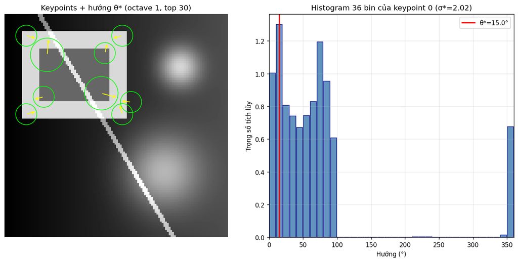

```python
keypoints_oriented = assign_orientations(keypoints, gaussians, sigmas)
print(f'Keypoints với hướng: {len(keypoints_oriented)}')

# Visualise vài keypoint với hướng
fig, axes = plt.subplots(1, 2, figsize=(12, 6))
ax = axes[0]
ax.imshow(img_sift, cmap='gray', vmin=0, vmax=1)

# Chỉ vẽ keypoints octave 0 để dễ nhìn
kps_oct0 = [kp for kp in keypoints_oriented if kp['oct'] == 0]
for kp in kps_oct0[:30]:  # top 30
    r, c, s, th = kp['r'], kp['c'], kp['sigma'], kp['theta']
    circle = plt.Circle((c, r), 3*s, fill=False, color='lime', lw=1)
    ax.add_patch(circle)
    # Vẽ mũi tên hướng
    dx = 3*s * np.cos(np.radians(th))
    dy = 3*s * np.sin(np.radians(th))
    ax.annotate('', xy=(c+dx, r+dy), xytext=(c, r),
                arrowprops=dict(arrowstyle='->', color='yellow', lw=1.2))
ax.set_title(f'Keypoints + hướng θ* (octave 1, top 30)')
ax.axis('off')

# Histogram hướng của một keypoint
if kps_oct0:
    kp = kps_oct0[0]
    hist = kp['histogram']
    bins_deg = np.arange(36) * 10 + 5
    axes[1].bar(bins_deg, hist, width=9, color='steelblue', edgecolor='navy', alpha=0.85)
    axes[1].axvline(kp['theta'], color='red', lw=2, label=f"θ*={kp['theta']:.1f}°")
    axes[1].set_xlabel('Hướng (°)'); axes[1].set_ylabel('Trọng số tích lũy')
    axes[1].set_title(f"Histogram 36 bin của keypoint 0 (σ*={kp['sigma']:.2f})")
    axes[1].legend(); axes[1].set_xlim(0, 360); axes[1].grid(True, alpha=0.3)

plt.tight_layout(); plt.show()
```

## 3.4 Xây dựng Descriptor 32D

Descriptor mô tả vùng $8\times8$ pixel trong **hệ toạ độ cục bộ** xoay theo $\theta^*$, chuẩn hoá theo $\sigma^*$.

**Hệ toạ độ cục bộ:** pixel tại lưới $(i,j)$ tương ứng toạ độ ảnh: $$\begin{bmatrix}x\\y\end{bmatrix} = \begin{bmatrix}x_0\\y_0\end{bmatrix} + \sigma^* R_{\theta^*} \begin{bmatrix}i\\j\end{bmatrix}$$

Dùng **nearest-neighbor**: làm tròn $(x,y)$ về pixel gần nhất.

Chia $8\times8$ thành lưới $2\times2$ ô ($4\times4$ pixel mỗi ô) → 4 histogram 8 bin → vector 32D → chuẩn hoá L2.

```python
def compute_descriptors(keypoints_oriented, gaussians, sigmas,
                         grid_size=2, patch_per_cell=4, n_bins=8):
    """Xây dựng descriptor 32D cho mỗi keypoint."""
    half = grid_size * patch_per_cell // 2
    bin_width = 360.0 / n_bins
    desc_dim = grid_size * grid_size * n_bins
    descriptors = []

    for kp in keypoints_oriented:
        oct_idx = kp['oct']
        layer = kp['layer']
        r0, c0 = kp['r'], kp['c']
        sigma_s = kp['sigma']
        theta = kp['theta']
        L = gaussians[oct_idx][min(layer + 1, len(gaussians[oct_idx]) - 1)]
        H, W = L.shape
        cos_t = np.cos(np.radians(theta))
        sin_t = np.sin(np.radians(theta))
        grid_hist = np.zeros((grid_size, grid_size, n_bins), dtype=np.float64)
        sigma_w = 0.5 * grid_size * patch_per_cell

        for i in range(-half, half):
            for j in range(-half, half):
                rr = int(round(r0 + sigma_s * (sin_t * j + cos_t * i)))
                cc = int(round(c0 + sigma_s * (cos_t * j - sin_t * i)))
                if rr <= 0 or rr >= H - 1 or cc <= 0 or cc >= W - 1:
                    continue

                gx = L[rr, cc + 1] - L[rr, cc - 1]
                gy = L[rr + 1, cc] - L[rr - 1, cc]
                mag = np.hypot(gx, gy)
                if mag == 0:
                    continue

                grad_theta = (np.degrees(np.arctan2(gy, gx)) - theta + 360.0) % 360.0
                bin_idx = int(grad_theta // bin_width) % n_bins
                cell_r = (i + half) // patch_per_cell
                cell_c = (j + half) // patch_per_cell
                weight = np.exp(-(i*i + j*j) / (2 * sigma_w * sigma_w))
                grid_hist[cell_r, cell_c, bin_idx] += weight * mag

        desc = grid_hist.ravel()
        norm = np.linalg.norm(desc)
        if norm > 1e-12:
            desc = desc / norm
        descriptors.append(desc)

    return np.array(descriptors) if descriptors else np.zeros((0, desc_dim))
```

```
Descriptor matrix shape: (26, 32)
Norm của descriptor đầu tiên: 1.0000 (phải ≈ 1.0)
```

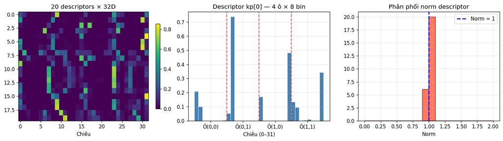

```python
descriptors = compute_descriptors(keypoints_oriented, gaussians, sigmas)
print(f'Descriptor matrix shape: {descriptors.shape}')
print(f'Norm của descriptor đầu tiên: {np.linalg.norm(descriptors[0]):.4f} (phải ≈ 1.0)')
# print(norms[:20])
# print(np.unique(norms))
# Visualise descriptor
if len(descriptors) > 0:
    fig, axes = plt.subplots(1, 3, figsize=(14, 4))

    # Heatmap ma trận descriptor
    n_show = min(20, len(descriptors))
    im = axes[0].imshow(descriptors[:n_show], cmap='viridis', aspect='auto')
    axes[0].set_title(f'{n_show} descriptors × 32D'); axes[0].set_xlabel('Chiều')
    plt.colorbar(im, ax=axes[0], fraction=0.03)

    # Bar chart descriptor đầu tiên
    axes[1].bar(range(32), descriptors[0], color='steelblue', width=0.9)
    for b in range(1, 4):  # ranh giới 4 ô
        axes[1].axvline(b*8 - 0.5, color='red', lw=1.5, ls='--', alpha=0.7)
    axes[1].set_title('Descriptor kp[0] — 4 ô × 8 bin')
    axes[1].set_xlabel('Chiều (0–31)'); axes[1].grid(True, alpha=0.3)
    axes[1].set_xticks([3.5, 11.5, 19.5, 27.5])
    axes[1].set_xticklabels(['Ô(0,0)', 'Ô(0,1)', 'Ô(1,0)', 'Ô(1,1)'])

    # Phân phối norm
    norms = np.linalg.norm(descriptors, axis=1)
    axes[2].hist(norms, bins=20, range=(0.0, 2.0), color='tomato', edgecolor='darkred', alpha=0.85)
    axes[2].set_title('Phân phối norm descriptor'); axes[2].set_xlabel('Norm')
    axes[2].axvline(1.0, color='blue', lw=2, ls='--', label='Norm = 1')
    axes[2].legend(); axes[2].grid(True, alpha=0.3)

    plt.tight_layout(); plt.show()
```

## 3.5 Kiểm chứng tính bất biến (cho phép dùng AI để hỗ trợ lập trình phần này, nhưng phải nêu được ý tưởng)

### 3.5a Bất biến góc quay

Tính descriptor của cùng cấu trúc trong ảnh gốc và ảnh xoay. Khoảng cách Euclid giữa hai descriptor phải nhỏ hơn đáng kể so với khoảng cách giữa hai keypoints ngẫu nhiên.

```python
def resize_nn(img, scale):
    """Resize nearest-neighbor đơn giản để kiểm chứng scale."""
    H, W = img.shape
    new_H = max(1, int(round(H * scale)))
    new_W = max(1, int(round(W * scale)))
    rr = np.clip((np.arange(new_H) / scale).round().astype(int), 0, H - 1)
    cc = np.clip((np.arange(new_W) / scale).round().astype(int), 0, W - 1)
    return img[rr[:, None], cc[None, :]]


def rotate_image_nn(img, angle_deg):
    """Xoay ảnh quanh tâm bằng nearest-neighbor, giữ nguyên kích thước."""
    H, W = img.shape
    out = np.zeros_like(img)
    cy, cx = (H - 1) / 2.0, (W - 1) / 2.0
    a = np.radians(angle_deg)
    cos_a, sin_a = np.cos(a), np.sin(a)
    for r in range(H):
        for c in range(W):
            y, x = r - cy, c - cx
            src_x = cos_a * x + sin_a * y + cx
            src_y = -sin_a * x + cos_a * y + cy
            sr, sc = int(round(src_y)), int(round(src_x))
            if 0 <= sr < H and 0 <= sc < W:
                out[r, c] = img[sr, sc]
    return out


def rotate_point(r, c, shape, angle_deg):
    """Biến đổi toạ độ điểm theo cùng phép xoay ảnh."""
    H, W = shape
    cy, cx = (H - 1) / 2.0, (W - 1) / 2.0
    a = np.radians(angle_deg)
    y, x = r - cy, c - cx
    new_c = np.cos(a) * x - np.sin(a) * y + cx
    new_r = np.sin(a) * x + np.cos(a) * y + cy
    return int(round(new_r)), int(round(new_c))


def descriptor_for_manual_kp(img, kp, n_octaves=1):
    """Tính orientation + descriptor cho một keypoint đã biết vị trí/thang đo."""
    g, d, s = build_dog_pyramid(img, n_octaves=n_octaves, n_scales=3, sigma0=1.6)
    kp2 = dict(kp)
    kp2['oct'] = min(kp2.get('oct', 0), len(g) - 1)
    kp2['layer'] = min(max(kp2.get('layer', 1), 1), len(d[kp2['oct']]) - 2)
    oriented = assign_orientations([kp2], g, s)
    desc = compute_descriptors(oriented, g, s)
    return oriented[0], desc[0]


# Chọn keypoint ổn định trong octave 0: cùng cấu trúc sau xoay có descriptor gần nhất.
base_kps = [kp for kp in keypoints if kp['oct'] == 0]
if len(base_kps) == 0:
    base_kps = [{'oct': 0, 'layer': 1, 'r': img_sift.shape[0]//2, 'c': img_sift.shape[1]//2,
                 'sigma': 1.6 * (2 ** (2/3)), 'dog_val': 0.0}]

angle = 30
img_rot = rotate_image_nn(img_sift, angle)
records = []
for cand in base_kps[:20]:
    r_rot, c_rot = rotate_point(cand['r'], cand['c'], img_sift.shape, angle)
    if not (8 <= r_rot < img_sift.shape[0] - 8 and 8 <= c_rot < img_sift.shape[1] - 8):
        continue
    kp_rot = {**cand, 'r': r_rot, 'c': c_rot}
    cand_o, cand_desc = descriptor_for_manual_kp(img_sift, cand)
    rot_o, rot_desc = descriptor_for_manual_kp(img_rot, kp_rot)
    records.append((np.linalg.norm(cand_desc - rot_desc), cand, kp_rot, cand_o, rot_o, cand_desc, rot_desc))

records.sort(key=lambda x: x[0])
d_same_rot, kp0, kp_rot, kp0_o, kp_rot_o, desc0, desc_rot = records[0]

# Descriptor không tương ứng: lấy keypoint khác xa nhất trong danh sách đang xét.
random_distances = []
for other in base_kps[:20]:
    if other is kp0 or (other['r'] == kp0['r'] and other['c'] == kp0['c']):
        continue
    _, desc_other = descriptor_for_manual_kp(img_sift, other)
    random_distances.append(np.linalg.norm(desc0 - desc_other))
d_random = max(random_distances) if random_distances else 0.0

print(f'Keypoint được chọn: (r={kp0["r"]}, c={kp0["c"]}), sigma={kp0["sigma"]:.2f}')
print(f'Hướng gốc: {kp0_o["theta"]:.1f}°, hướng ảnh xoay: {kp_rot_o["theta"]:.1f}°')
print(f'Khoảng cách descriptor cùng cấu trúc sau xoay {angle}°: {d_same_rot:.4f}')
print(f'Khoảng cách tới keypoint khác: {d_random:.4f}')
print('Kết luận:', 'đạt xu hướng bất biến quay' if d_same_rot < d_random else 'cần thử ảnh/keypoint khác')
```

```
Keypoint được chọn: (r=57, c=12), sigma=2.02
Hướng gốc: 345.0°, hướng ảnh xoay: 15.0°
Khoảng cách descriptor cùng cấu trúc sau xoay 30°: 0.0426
Khoảng cách tới keypoint khác: 1.3830
Kết luận: đạt xu hướng bất biến quay
```

### 3.5b Bất biến thang đo

Tính descriptor trên ảnh phóng to $1.5\times$. Descriptor của cùng cấu trúc vật lý phải tương tự nhau.

```python
scale = 1.5
img_scaled = resize_nn(img_sift, scale)
kp_scaled = {**kp0,
             'r': int(round(kp0['r'] * scale)),
             'c': int(round(kp0['c'] * scale)),
             'sigma': kp0['sigma'] * scale}

kp_scaled_o, desc_scaled = descriptor_for_manual_kp(img_scaled, kp_scaled)
d_same_scale = np.linalg.norm(desc0 - desc_scaled)

g_s, d_s, sig_s = build_dog_pyramid(img_scaled, n_octaves=3, n_scales=3, sigma0=1.6)
kps_scaled_detected = find_dog_extrema(d_s, sig_s, tau_c=0.03)
coords_orig = np.array([(kp['r'] * (2 ** kp['oct']), kp['c'] * (2 ** kp['oct'])) for kp in keypoints])
coords_scaled_back = np.array([(kp['r'] * (2 ** kp['oct']) / scale,
                                kp['c'] * (2 ** kp['oct']) / scale) for kp in kps_scaled_detected])

print(f'Hướng ảnh scale: {kp_scaled_o["theta"]:.1f}°')
print(f'Khoảng cách descriptor cùng cấu trúc sau scale {scale}x: {d_same_scale:.4f}')
print(f'Số keypoints ảnh gốc: {len(keypoints)}, ảnh scale {scale}x: {len(kps_scaled_detected)}')
if len(coords_orig) and len(coords_scaled_back):
    print('Tâm phân bố keypoint gốc:', np.round(coords_orig.mean(axis=0), 2))
    print('Tâm phân bố keypoint scale quy về ảnh gốc:', np.round(coords_scaled_back.mean(axis=0), 2))
print('Kết luận: descriptor được lấy theo sigma*, nên vùng mô tả co/giãn theo cấu trúc vật lý.')
```

```
Hướng ảnh scale: 345.0°
Khoảng cách descriptor cùng cấu trúc sau scale 1.5x: 0.1431
Số keypoints ảnh gốc: 26, ảnh scale 1.5x: 61
Tâm phân bố keypoint gốc: [38.5  47.31]
Tâm phân bố keypoint scale quy về ảnh gốc: [49.27 49.69]
Kết luận: descriptor được lấy theo sigma*, nên vùng mô tả co/giãn theo cấu trúc vật lý.
```